# PROCEDIMIENTOS QUIRÚRGICOS CON TIEMPOS DE ESPERA LIMITADOS

jaime.pinilla@ulpgc.es

26/11/2024

## 1 Acceso a la presentación

**https://jpinilla.github.io/Meeting-Atlas/Resultados4.html**

[figure not shown]

## 2 Objetivo

Las fluctuaciones de las entradas y salidas de las listas de espera (LE) quirúrgica son numerosas y cambiantes en el tiempo. Identificar las causas de estas fluctuaciones, resulta clave para cualquier estrategia destinada a buscar el equilibrio. En este trabajo, proponemos un análisis empírico sobre los factores que están detrás del comportamiento de las salidas de la lista de espera para cirugía electiva.

### 2.1 La estacionalidad del movimiento, salidas, de las listas de espera

La pandemia ha invertido este porcentaje superando el segundo semestre al primero, probablemente muy relacionado con las diferentes oleadas de COVID-19.

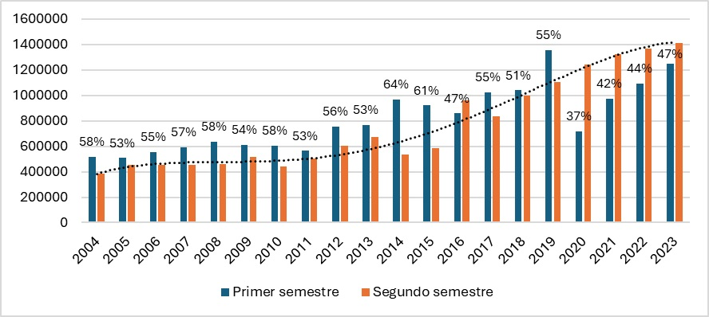

**Evolución de las salidas de la lista de espera por intervención en cirugía electiva.** *Datos del Sistema de Información de Listas de Espera del Sistema Nacional de Salud*.

Nota: Hasta 2011 sin datos de las Comunidades de Madrid y Cataluña, en 2015 se incorporan los datos de Madrid y en 2016 los de Cataluña.

Un problema importante del análisis de los datos del SISLE es que no se proporcionan desagregados por CCAA, además, para algunos periodos la serie no contiene la información de la Comunidad de Madrid y Cataluña.

Los datos del SISLE se recopilan **sólo en dos periodos o ventanas**, primer y segundo semestre de cada año. Para el objetivo de nuestro estudio necesitamos datos con una periodicidad como mínimo mensual.

Nuestra aproximación propone medir la variabilidad de las salidas en LE, utilizando como proxy la variabilidad en la actividad quirúrgica en los porcesos relacionados con dicha LE.

## 3 Material y métodos

Procesos o patologías contempladas en el RD 605/2003 y OCDE/ RD. 1039/2011

Distinguimos entre **cirugía electiva**: Cataratas; Hernia inguinal femoral, Prótesis de cadera; Artroscopias; Varices; Colecistectomía; Quiste pilonidal; Adeno-amigdalectomía; Prostatectomías; Túnel carpiano; Prótesis rodilla; Histerectomía; Hallux valgas.

**Cirugía urgente**: Cirugía de bypass aórtico-coronario en mayores de 40 años; Angioplastia coronaria transluminal percutánea en mayores de 40 años; Añadimos fuera de los contemplados en los Reales Decretos Ingreso por infarto miocardio en mayores de 40 años; Cirugía de cadera después de ingreso urgente por fractura de cadera en mayores de 65 años; Cirugía de cáncer de mama en mujeres adultas hasta 85 años. Trabajamos con el agregado nacional de 14 CCAA. Quedan fuera por falta de datos: Castilla y León, Cataluña y Galicia.

## 4 Análisis de series temporales

[interactive chart not shown]

### 4.1 Análisis de la estacionalidad (datos mensuales)

[interactive chart not shown]

### 4.2 Evolución de la estacionalidad a lo largo de los años

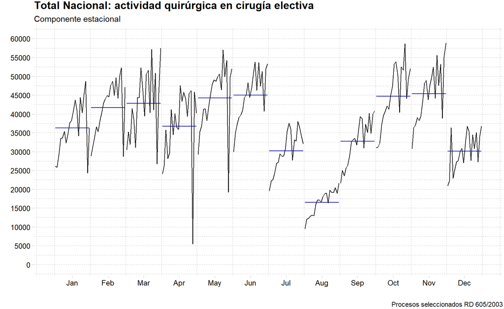

### 4.3 Descomposición de la serie asumiendo un esquema multiplicativo

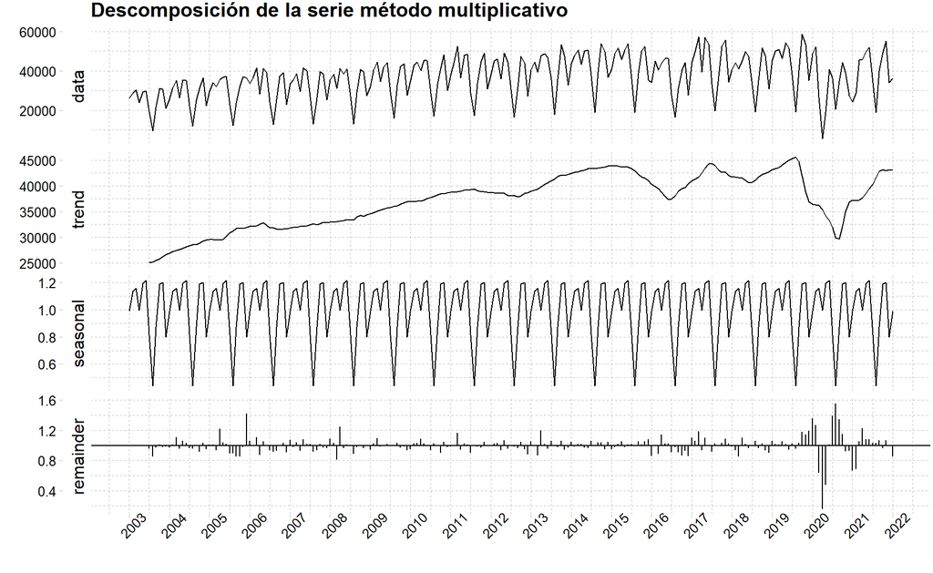

### 4.4 Tasas de variación estacional

```
##       Ene       Feb       Mar       Abr       May       Jun       Jul       Ago
## 0.9869857 1.1338463 1.1588283 0.9938253 1.1921494 1.2144454 0.8158554 0.4404831
##       Sep       Oct       Nov       Dic
## 0.8734224 1.1903552 1.2008537 0.7989499
```

## 5 Análisis por procesos

Comparación de la estacionalidad para procesos no urgentes y procesos urgentes

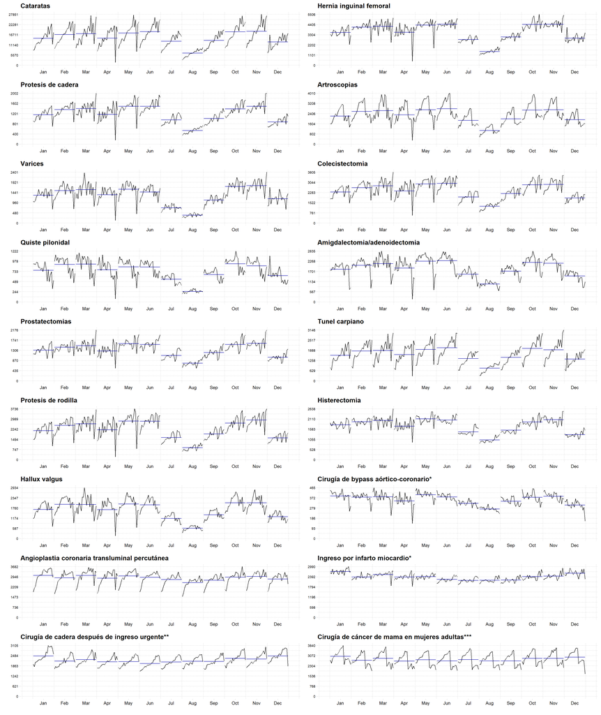

## 6 Análisis de la variabilidad mensual de la serie a lo largo de los años

El coeficiente de variación mide la variación de los datos respecto a la media, sin tener en cuenta las unidades de medida.

Si el coeficiente de variación está próximo a 0, significa que existe poca variabilidad en los datos y por tanto la distribución de datos es muy homogénea. En cambio, si se acerca o supera el el valor 1 se consideran datos muy dispersos.

| Año | Proceso | Media | Desviación típica | Coef. variación | Tipo |
| --- | --- | --- | --- | --- | --- |
| 2003 | Cataratas | 7958.33333333333 | 1949.70619387236 | 0.244989259963019 | Cirugía electiva |
| 2004 | Cataratas | 9488.5 | 2390.48848184177 | 0.25193534086966 | Cirugía electiva |
| 2005 | Cataratas | 10796.5 | 3004.07709318822 | 0.27824545854566 | Cirugía electiva |
| 2006 | Cataratas | 11403.75 | 3069.41679758105 | 0.269158548510889 | Cirugía electiva |
| 2007 | Cataratas | 11448.0833333333 | 2900.82513209082 | 0.253389589124015 | Cirugía electiva |
| 2008 | Cataratas | 11941.5 | 2847.5442529884 | 0.238457836367994 | Cirugía electiva |
| 2009 | Cataratas | 13217.0833333333 | 3068.86675732956 | 0.232189408202482 | Cirugía electiva |
| 2010 | Cataratas | 14164.75 | 3297.58884710412 | 0.232802474247983 | Cirugía electiva |
| 2011 | Cataratas | 15059 | 3819.04688252306 | 0.253605610101803 | Cirugía electiva |
| 2012 | Cataratas | 14967.3333333333 | 3789.28969917086 | 0.253170662721317 | Cirugía electiva |

[output cut: 350 more lines]

### 6.1 Gráfico de dispersión de los coeficientes de variación

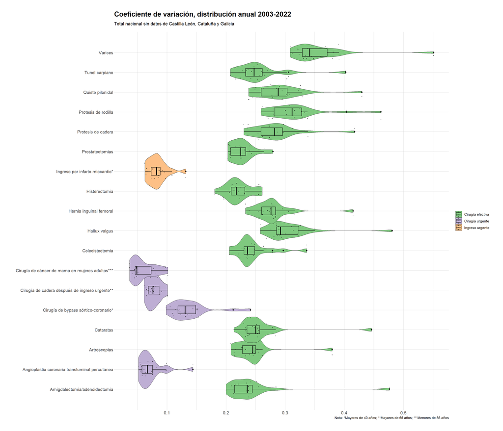

## 7 Estimación de cirugías perdidas, corrección por estacionalidad

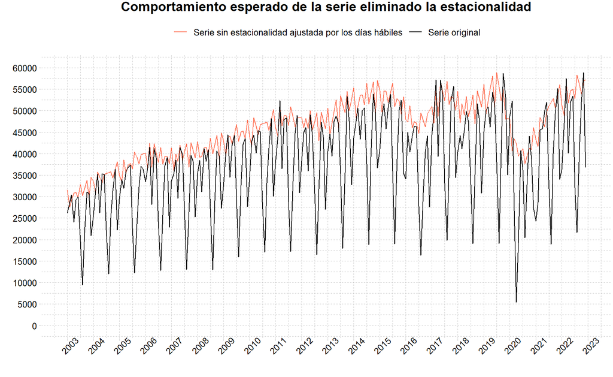

### 7.1 Resultados

Total cirugías en la serie original

```
## [1] 8928476
```

Total cirugías en la serie ajustada

```
## [1] 10995821
```

Diferencia

```
## [1] 2067345
```

Incremento proporcional

```
## [1] 23.15451
```

## 8 Ejercicio de robustez

Como prueba de robustez de nuestra aproximación, utilizamos datos de una Comunidad Autónoma que publica información sobre entradas y salidas de la lista de espera estructural.

Estandarizamos los valores de las respectivas series y los representamos en un mismo gráfico.

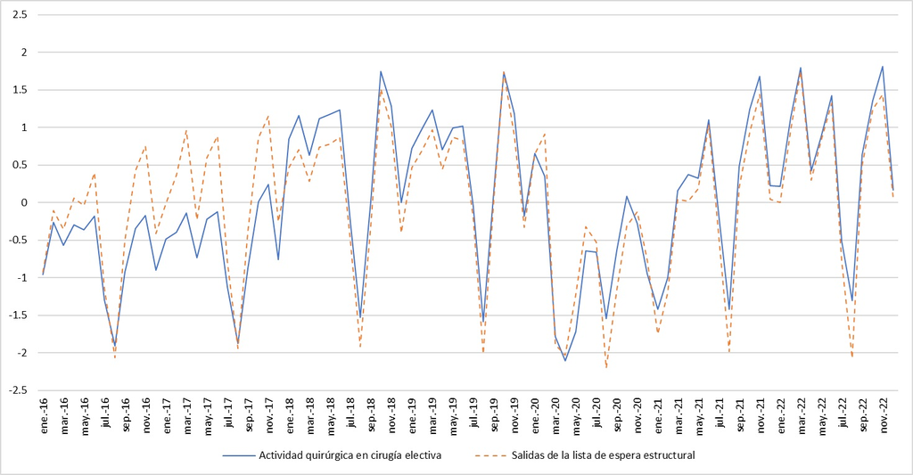

**Comparativa entre salidas de la lista de espera y número de cirugías** *Cirugía electiva*.

Nota: Series estandarizadas.

## 9 A modo de conclusión

“La evolución anual del número de pacientes en listas de espera puede representarse fácilmente por una curva sinusoidal. El usual buen comportamiento de la serie en los 6 primeros meses se sigue de un incremento de la lista en verano (es práctica habitual el cierre de unidades de enfermería); la serie vuelve a bajar en el último trimestre por efecto de los programas excepcionales (ya no tanto) de finales de año.”

[figure not shown]

**E. Bernal**. ¿Ha llegado la hora de la gestión de las listas de espera? Gaceta sanitaria 2002; 16(5):436-9